# Were the 2013 Houston Astros the Worst Team in Baseball?

By: Joseph Dunkin

## Introduction

As an Astros fan, I had the absolute pleasure of living through the tragedy that was the 2013 Houston Astros. I fondly remember going to Astros games every other week with friends just to see the Astros embarass themselves on the field game after game. The 2013 season was the worst season for any Houston sports team in the recent past, rivaling that of the 2011 and 2012 Astros who were almost just as awful. It was quite astounding on how often a baseball team could lose, and do it at such a high rate three years in a row. In this data science tutorial, I will investigate and use data analysis to determine whether the 2013 Houston Astros were the worst team in baseball.

## Data Scraping

First before we start acquiring data, we must import the necessary libraries in order to obtain the data, structure the data, and process the data for further analysis.

```python
import pandas as pd
import sqlite3
import numpy as np
import matplotlib.pyplot as plt
import seaborn as sns
```

## Source

Our source will be the seanlahman database for MLB statistics, a massive database containing data for teams, players, and league-wide statistics. The data is neatly organized in an sqlite database, which will be convenient for datascraping with sqlite. Since we are investigating the Houston Astors, a team, we will be primarily scraping data from the Teams table within the database, as other specific data is not the focus of this investigation.

In order to begin datascraping, we will need access to the sqlite file of the database. This can be found here: https://github.com/jknecht/baseball-archive-sqlite/raw/master/lahman2014.sqlite

```python
#First setup the sqlite file and connect to it to establish a connection to the sqlite database.
sqlite_file = 'lahman2014.sqlite'
conn = sqlite3.connect(sqlite_file)

#Query to convert data from sqlite to a pandas dataframe
team_query = "SELECT * FROM Teams \
  GROUP BY Teams.yearID"

#Use the query to create a team stats dataframe
tstats = pd.read_sql(team_query, conn)

#Show the dataframe
tstats.head()
```

|  | yearID | lgID | teamID | franchID | divID | Rank | G | Ghome | W | L | ... | DP | FP | name | park | attendance | BPF | PPF | teamIDBR | teamIDlahman45 | teamIDretro |
| --- | --- | --- | --- | --- | --- | --- | --- | --- | --- | --- | --- | --- | --- | --- | --- | --- | --- | --- | --- | --- | --- |
| 0 | 1871 | NA | BS1 | BNA | None | 3 | 31 | NaN | 20 | 10 | ... | NaN | 0.83 | Boston Red Stockings | South End Grounds I | NaN | 103 | 98 | BOS | BS1 | BS1 |
| 1 | 1872 | NA | BL1 | BLC | None | 2 | 58 | NaN | 35 | 19 | ... | NaN | 0.82 | Baltimore Canaries | Newington Park | NaN | 106 | 102 | BAL | BL1 | BL1 |
| 2 | 1873 | NA | BL1 | BLC | None | 3 | 57 | NaN | 34 | 22 | ... | NaN | 0.85 | Baltimore Canaries | Newington Park | NaN | 101 | 102 | BAL | BL1 | BL1 |
| 3 | 1874 | NA | BL1 | BLC | None | 8 | 47 | NaN | 9 | 38 | ... | NaN | 0.81 | Baltimore Canaries | Newington Park | NaN | 102 | 104 | BAL | BL1 | BL1 |
| 4 | 1875 | NA | BR2 | BRA | None | 11 | 44 | NaN | 2 | 42 | ... | NaN | 0.80 | Brooklyn Atlantics | Union Grounds | NaN | 88 | 94 | BRA | BR2 | BR2 |

5 rows × 48 columns

## Data Tidying

Now that we have obtained the data, and put it all into a table, we can begin tidying the data to make it fit our specific experiment.

We can begin by removing unwanted information from the dataframe. This includes:

- Data from years that aren't 2013, the year our investigation is based on.
- Statistics that aren't relevant to our investigation: this includes most of the columns except: Name, Year, Games, Wins, Losses, Runs allowed, Runs scored, Hits allowed, Hits, and a few others to keep track of the teams.

In order to do this, we will simply modify the sql query and recreate the dataframe. This allows us to rename the columns as we extract the information, making the entire process more streamlined.

```python
#New Query to convert data from sqlite to a pandas dataframe

#The grammar to select specific columns is: Teams.(Column you want) AS (Column name you want to set as)
#We also use "Where Teams.yearID == '2013'" to select data from only the year 2013
#We then use GROUP BY to sort the table by teamID
team_query = "SELECT \
  Teams.yearID AS Year, \
  Teams.teamID AS Team, \
  Teams.Rank AS Rank, \
  Teams.lgID AS League, \
  Teams.divID AS Division, \
  Teams.G AS Games, \
  Teams.W AS Wins, \
  Teams.L AS Losses, \
  Teams.R AS Runs_Scored, \
  Teams.RA AS Runs_Allowed, \
  Teams.ERA AS ERA, \
  Teams.AB AS AtBats, \
  Teams.H AS Hits, \
  Teams.HA AS Hits_Allowed, \
  Teams.BPF AS BPF, \
  Teams.PPF AS PPF \
  FROM Teams Where Teams.yearID == '2013' \
  GROUP BY Teams.teamID"

#Use the new query to create a team stats dataframe
tstats = pd.read_sql(team_query, conn)

#Show the dataframe
tstats
```

|  | Year | Team | Rank | League | Division | Games | Wins | Losses | Runs_Scored | Runs_Allowed | ERA | AtBats | Hits | Hits_Allowed | BPF | PPF |
| --- | --- | --- | --- | --- | --- | --- | --- | --- | --- | --- | --- | --- | --- | --- | --- | --- |
| 0 | 2013 | ARI | 2 | NL | W | 162 | 81 | 81 | 685 | 695 | 3.92 | 5676 | 1468 | 1460 | 102 | 102 |
| 1 | 2013 | ATL | 1 | NL | E | 162 | 96 | 66 | 688 | 548 | 3.18 | 5441 | 1354 | 1326 | 104 | 103 |
| 2 | 2013 | BAL | 3 | AL | E | 162 | 85 | 77 | 745 | 709 | 4.20 | 5620 | 1460 | 1438 | 106 | 105 |
| 3 | 2013 | BOS | 1 | AL | E | 162 | 97 | 65 | 853 | 656 | 3.79 | 5651 | 1566 | 1366 | 102 | 102 |
| 4 | 2013 | CHA | 5 | AL | C | 162 | 63 | 99 | 598 | 723 | 3.98 | 5563 | 1385 | 1424 | 104 | 105 |
| 5 | 2013 | CHN | 5 | NL | C | 162 | 66 | 96 | 602 | 689 | 4.00 | 5498 | 1307 | 1332 | 107 | 107 |
| 6 | 2013 | CIN | 3 | NL | C | 162 | 90 | 72 | 698 | 589 | 3.38 | 5499 | 1370 | 1294 | 103 | 102 |
| 7 | 2013 | CLE | 2 | AL | C | 162 | 92 | 70 | 745 | 662 | 3.82 | 5465 | 1391 | 1359 | 93 | 94 |
| 8 | 2013 | COL | 5 | NL | W | 162 | 74 | 88 | 706 | 760 | 4.44 | 5599 | 1511 | 1545 | 117 | 118 |
| 9 | 2013 | DET | 1 | AL | C | 162 | 93 | 69 | 796 | 624 | 3.61 | 5735 | 1625 | 1369 | 106 | 105 |
| 10 | 2013 | HOU | 5 | AL | W | 162 | 51 | 111 | 610 | 848 | 4.79 | 5457 | 1307 | 1530 | 99 | 101 |
| 11 | 2013 | KCA | 3 | AL | C | 162 | 86 | 76 | 648 | 601 | 3.45 | 5549 | 1443 | 1366 | 103 | 103 |
| 12 | 2013 | LAA | 3 | AL | W | 162 | 78 | 84 | 733 | 737 | 4.23 | 5588 | 1476 | 1475 | 94 | 94 |
| 13 | 2013 | LAN | 1 | NL | W | 162 | 92 | 70 | 649 | 582 | 3.25 | 5491 | 1447 | 1321 | 95 | 95 |
| 14 | 2013 | MIA | 5 | NL | E | 162 | 62 | 100 | 513 | 646 | 3.71 | 5449 | 1257 | 1376 | 102 | 103 |
| 15 | 2013 | MIL | 4 | NL | C | 162 | 74 | 88 | 640 | 687 | 3.84 | 5474 | 1381 | 1401 | 105 | 105 |
| 16 | 2013 | MIN | 4 | AL | C | 162 | 66 | 96 | 614 | 788 | 4.55 | 5564 | 1346 | 1591 | 99 | 101 |
| 17 | 2013 | NYA | 4 | AL | E | 162 | 85 | 77 | 650 | 671 | 3.94 | 5449 | 1321 | 1452 | 102 | 101 |
| 18 | 2013 | NYN | 4 | NL | E | 162 | 74 | 88 | 619 | 684 | 3.77 | 5559 | 1318 | 1442 | 94 | 95 |
| 19 | 2013 | OAK | 1 | AL | W | 162 | 96 | 66 | 767 | 625 | 3.56 | 5521 | 1403 | 1339 | 95 | 93 |
| 20 | 2013 | PHI | 4 | NL | E | 162 | 73 | 89 | 610 | 749 | 4.32 | 5456 | 1355 | 1465 | 101 | 102 |
| 21 | 2013 | PIT | 2 | NL | C | 162 | 94 | 68 | 634 | 577 | 3.26 | 5486 | 1346 | 1299 | 94 | 94 |
| 22 | 2013 | SDN | 3 | NL | W | 162 | 76 | 86 | 618 | 700 | 3.98 | 5517 | 1349 | 1407 | 91 | 91 |
| 23 | 2013 | SEA | 4 | AL | W | 162 | 71 | 91 | 624 | 754 | 4.31 | 5558 | 1318 | 1467 | 92 | 92 |
| 24 | 2013 | SFN | 4 | NL | W | 162 | 76 | 86 | 629 | 691 | 4.00 | 5552 | 1446 | 1380 | 90 | 89 |
| 25 | 2013 | SLN | 1 | NL | C | 162 | 97 | 65 | 783 | 596 | 3.42 | 5557 | 1494 | 1366 | 99 | 97 |
| 26 | 2013 | TBA | 2 | AL | E | 163 | 92 | 71 | 700 | 646 | 3.74 | 5538 | 1421 | 1315 | 96 | 95 |
| 27 | 2013 | TEX | 2 | AL | W | 163 | 91 | 72 | 730 | 636 | 3.62 | 5585 | 1465 | 1370 | 104 | 103 |
| 28 | 2013 | TOR | 5 | AL | E | 162 | 74 | 88 | 712 | 756 | 4.25 | 5537 | 1398 | 1451 | 102 | 102 |
| 29 | 2013 | WAS | 2 | NL | E | 162 | 86 | 76 | 656 | 626 | 3.59 | 5436 | 1365 | 1367 | 102 | 101 |

Now we have selected the columns from the entire dataset that we want, and have tidied the data to match our investigation parameters. All the data is now from 2013, and neatly organized by team to make it easier to analyze.

To complete the data tidying, we need to convert all numeric data to numeric types in the panda dataframe in order to use them as numeric values down the line during the analysis. To do this, we can simply use to_numeric that is built into the panda package.

```python
#Convert all the numeric columns to numeric type in the dataframe
tstats["Games"] = pd.to_numeric(tstats["Games"])
tstats["Wins"] = pd.to_numeric(tstats["Wins"])
tstats["Losses"] = pd.to_numeric(tstats["Losses"])
tstats["Runs_Scored"] = pd.to_numeric(tstats["Runs_Scored"])
tstats["Runs_Allowed"] = pd.to_numeric(tstats["Runs_Allowed"])
tstats["ERA"] = pd.to_numeric(tstats["ERA"])
tstats["AtBats"] = pd.to_numeric(tstats["AtBats"])
tstats["Hits"] = pd.to_numeric(tstats["Hits"])
tstats["Hits_Allowed"] = pd.to_numeric(tstats["Hits_Allowed"])
tstats["BPF"] = pd.to_numeric(tstats["BPF"])
tstats["PPF"] = pd.to_numeric(tstats["PPF"])

#Show the head of the updated table
tstats.head()
```

|  | Year | Team | Rank | League | Division | Games | Wins | Losses | Runs_Scored | Runs_Allowed | ERA | AtBats | Hits | Hits_Allowed | BPF | PPF |
| --- | --- | --- | --- | --- | --- | --- | --- | --- | --- | --- | --- | --- | --- | --- | --- | --- |
| 0 | 2013 | ARI | 2 | NL | W | 162 | 81 | 81 | 685 | 695 | 3.92 | 5676 | 1468 | 1460 | 102 | 102 |
| 1 | 2013 | ATL | 1 | NL | E | 162 | 96 | 66 | 688 | 548 | 3.18 | 5441 | 1354 | 1326 | 104 | 103 |
| 2 | 2013 | BAL | 3 | AL | E | 162 | 85 | 77 | 745 | 709 | 4.20 | 5620 | 1460 | 1438 | 106 | 105 |
| 3 | 2013 | BOS | 1 | AL | E | 162 | 97 | 65 | 853 | 656 | 3.79 | 5651 | 1566 | 1366 | 102 | 102 |
| 4 | 2013 | CHA | 5 | AL | C | 162 | 63 | 99 | 598 | 723 | 3.98 | 5563 | 1385 | 1424 | 104 | 105 |

Lastly in order to compare team ERA with batting average in our analysis, we have to make a new column showing each team's batting average. This can be done by simply dividing Hits with AtBats, as that represents the batting average of the team.

```python
#First get the Batting average of each team by dividing Hits by AtBats
tstats["BA"] = (tstats["Hits"]/tstats["AtBats"])

#We then round the batting average to 3 decimals as they are traditionally represented in baseball
tstats["BA"] = tstats["BA"].round(decimals=3)

#Show the head of the new table to confirm the addition of the column
tstats.head()
```

|  | Year | Team | Rank | League | Division | Games | Wins | Losses | Runs_Scored | Runs_Allowed | ERA | AtBats | Hits | Hits_Allowed | BPF | PPF | BA |
| --- | --- | --- | --- | --- | --- | --- | --- | --- | --- | --- | --- | --- | --- | --- | --- | --- | --- |
| 0 | 2013 | ARI | 2 | NL | W | 162 | 81 | 81 | 685 | 695 | 3.92 | 5676 | 1468 | 1460 | 102 | 102 | 0.259 |
| 1 | 2013 | ATL | 1 | NL | E | 162 | 96 | 66 | 688 | 548 | 3.18 | 5441 | 1354 | 1326 | 104 | 103 | 0.249 |
| 2 | 2013 | BAL | 3 | AL | E | 162 | 85 | 77 | 745 | 709 | 4.20 | 5620 | 1460 | 1438 | 106 | 105 | 0.260 |
| 3 | 2013 | BOS | 1 | AL | E | 162 | 97 | 65 | 853 | 656 | 3.79 | 5651 | 1566 | 1366 | 102 | 102 | 0.277 |
| 4 | 2013 | CHA | 5 | AL | C | 162 | 63 | 99 | 598 | 723 | 3.98 | 5563 | 1385 | 1424 | 104 | 105 | 0.249 |

Now that the table is tidy, I will elaborate on each of the columns for you to get a better understanding of what they represent.

Team : TeamID as represented in the database: ARI = Arizona Diamondbacks

Rank : Their ranking in their division (Each league has 3 divisions: West, East, and Central hence the repeats in rank)

League/Division : Their League (American League or National League) and division (West, East or Central)

Games/Wins/Losses : Games played, Games won, and Games lost

Runs_Scored/Runs_Allowed : Cumulative runs scored and allowed throughout the season (Run = Point in baseball)

ERA : Average earned runs allowed per game (Different from runs allowed as runs earned off of fielder errors are not counted. This makes ERA a primarily pitching statistic)

AtBats/Hits/Hits_Allowed : Team cumulative at bats and hits/hits allowed during the season

BPF/PPF : Three-year park factor for batters/pitchers, will be explained more in detail later

BA : Team batting average for the 2013 season

## Data Visualization and Data Analysis

Now that the data has been tidied up, we can begin to display our data in graphs, and begin analyzing whether or not the Houston Astros were the worst team in baseball in 2013.

We will begin by creating a scatter plot comparing ERA and BA. This is a widely used metric to determine the state of a team, as Wins and Losses can sometimes be an inaccurate reflection of a team's performance. We will divide the scatter plot into 4 quadrants to clarify what category each team falls into compared to the rest of the league.

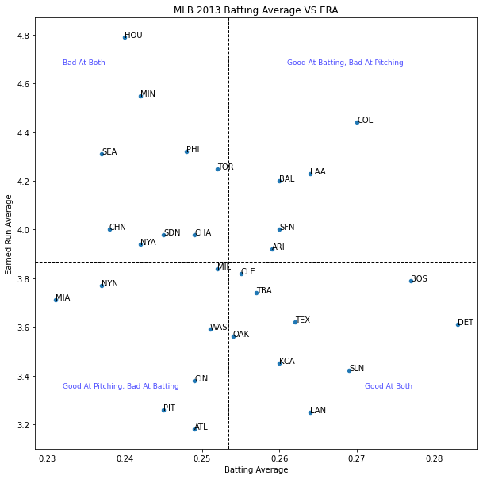

```python
#First we plot the graph itself

#Scatter plot with BA on the x axis, and ERA on the y axis
ax = tstats.plot(x='BA',y='ERA',kind='scatter',figsize=(10,10))
#title
ax.title.set_text('MLB 2013 Batting Average VS ERA')
#labeling for all the teams
tstats[['BA','ERA','Team']].apply(lambda x: ax.text(*x),axis=1)
#labeling for x and y axis
ax.set_xlabel('Batting Average')
ax.set_ylabel('Earned Run Average')

#add horizontal and vertical lines of the league averages to form the quadrants
plt.axhline(y=tstats['ERA'].mean(), color='k', linestyle='--', linewidth=1)
plt.axvline(x=tstats['BA'].mean(), color='k',linestyle='--', linewidth=1)


#we label the quadrants (little bit of trial and error to get the positioning right)
plt.text(x=0.261, y=4.68, s="Good At Batting, Bad At Pitching",alpha=0.7,fontsize=9, color='b')
plt.text(x=0.232, y=3.35, s="Good At Pitching, Bad At Batting",alpha=0.7,fontsize=9, color='b')
plt.text(x=0.271, y=3.35, s="Good At Both",alpha=0.7,fontsize=9, color='b')
plt.text(x=0.232, y=4.68, s="Bad At Both",alpha=0.7,fontsize=9, color='b')

#show the plot
plt.show()
```

As expected, the Astros aren't looking so hot in terms of the team's performance. Compared to the rest of the league, we are placed firmly in the quadrant representing teams that are both bad at pitching and bad at hitting. When we look at the exact positioning of the Astros, one can see that the Astros are the worst pitching team in the league by far. Our ERA is far higher than the second worst, Minnesota Twins, at a staggering ERA of about 4.8. To put in perspective, the average ERA in 2013 was 3.86. This means the Astros, on average, allowed an entire run more than the league average. Now one run doesn't sound like a lot, but this one run can be represented as the Astros allowing 24% more runs than the league average, which puts in perspective how awful their pitching was.

Their hitting on the other hand was still pretty bad. The Houston Astors batted .240 in the 2013 season. While not absolutely atrocious like the Miami Marlin's .231, it was still pretty bad. To put in perspective, the league average was .255, and some of the best teams were batting closer to .280 this year. While not as bad as the pitching, the Astros hitters were well below average.

In order to determine whether this combination of bad pitching and bad hitting warrants the Astros the title worst baseball team in 2013, we have to look deeper into the data to reach a definitive conclusion.

## Data Adjustment and Standardization

After the initial analysis we have a general idea on where the Astros stand in 2013. While they are definitely one of the worst teams, we need to find a way to quantify definitively whether or not they were the worst.

The way we are going to do this is to measure their expected win percentage using the Sabrmetrics method.

The equation for expected win percentage is EXP(W%) = (RS)^2 / [(RS)^2 + (RA)^2] where RS = Runs scored, and RA = Runs Allowed

However, it is not as simple as plugging in the numbers. If we want to get a complete accurate assessment of the 2013 season, we will have to factor in ballpark favorability. This is where BPF and PPF come in.

BPF/PFF, or Batting Park Factor is a statistic that quantifies the contribution of a team's home stadium to their offensive production as well as pitching production.

More Information on BPF/PFF: https://en.wikipedia.org/wiki/Batting_park_factor

In order to get an accurate representation of how many runs a scores/allowed, we can adjust using the Park Factor to get a more standardized playing field to analyze team's expected winning percentage.

To do this, we will create a new dataframe that contains only a few columns of key data:

- Team Name (TEAM)
- Runs Scored/Runs Allowed (RS, RA)
- BPF and PFF (BPF, PFF)
- Adjusted Runs Scored/Runs Allowed (ARS, ARA)
- True Expected Winning Percentage (TEWP)

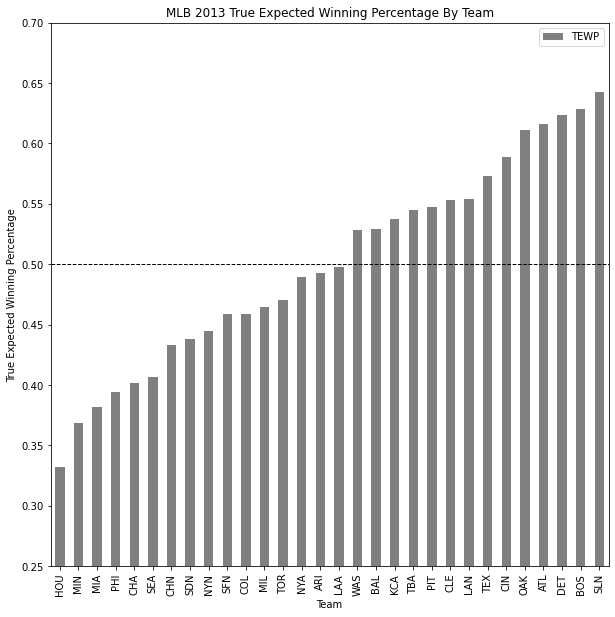

```python
#Make a new dataframe
newData = pd.DataFrame()

#Set team, Runs scored, and runs allowed from tstats
newData['TEAM'] = tstats['Team']
newData['RS'] = tstats['Runs_Scored']
newData['RA'] = tstats['Runs_Allowed']

#turn the BPF and PFF into multipliers to modify the adjusted runs scored/allowed
newData['BPF'] = tstats['BPF']/100
newData['PPF'] = tstats['PPF']/100

#create the adjusted runs scored/allowed
newData['ARS'] = newData['RS'] * newData['BPF']
newData['ARA'] = newData['RA'] * newData['PPF']

#using the adjusted runs scored and allowed, we create the True Expected Win Percentage
newData['TEWP'] = ((newData['ARS']*newData['ARS'])/((newData['ARS']*newData['ARS'])+(newData['ARA']*newData['ARA'])))

#sort the dataframe by TEWP
newData.sort_values('TEWP', inplace=True)
#plot the data in a bar plot
ax = newData.plot.bar(x='TEAM', y='TEWP', color = "grey", figsize=(10,10))
#title the plot
ax.title.set_text('MLB 2013 True Expected Winning Percentage By Team')
#labeling for x and y axis
ax.set_xlabel('Team')
ax.set_ylabel('True Expected Winning Percentage')

#show the mean (0.5, or 50% winning percentage)
plt.axhline(y=newData['TEWP'].mean(), color='k', linestyle='--', linewidth=1)
#set the limits to make the plot look nicer
plt.ylim((0.25, 0.7))
#show the plot
plt.show()
```

Now that we have the true expected win percentage, we can clearly see that the Houston Astros are at the bottom of the chart. This is not looking good for them. Now in order to get the definitive rankings of the teams in 2013, we will standardize the true winning percentage to see how bad the 2013 Houston Astros truly were.

In order to standardize the TEWP, we will have to first get the mean TEWP for 2013, as well as the standard deviation. We can then apply the standardization formula to create a new column in the newData dataframe to represent the standardized TEWP for all teams in 2013.

```python
#first get the mean by using .mean()
meanTEWP = newData['TEWP'].mean()

#then get the standard deviation using numpy's built in std() function
stdTEWP = np.std(newData['TEWP'])

#set the stdTEWP column using the standardization formula
newData['stdTEWP'] = (newData['TEWP'] - meanTEWP) / stdTEWP

#show the new column
newData.head()
```

|  | TEAM | RS | RA | BPF | PPF | ARS | ARA | TEWP | stdTEWP |
| --- | --- | --- | --- | --- | --- | --- | --- | --- | --- |
| 10 | HOU | 610 | 848 | 0.99 | 1.01 | 603.90 | 856.48 | 0.332068 | -2.009136 |
| 16 | MIN | 614 | 788 | 0.99 | 1.01 | 607.86 | 795.88 | 0.368418 | -1.575261 |
| 14 | MIA | 513 | 646 | 1.02 | 1.03 | 523.26 | 665.38 | 0.382120 | -1.411720 |
| 20 | PHI | 610 | 749 | 1.01 | 1.02 | 616.10 | 763.98 | 0.394063 | -1.269166 |
| 4 | CHA | 598 | 723 | 1.04 | 1.05 | 621.92 | 759.15 | 0.401606 | -1.179128 |

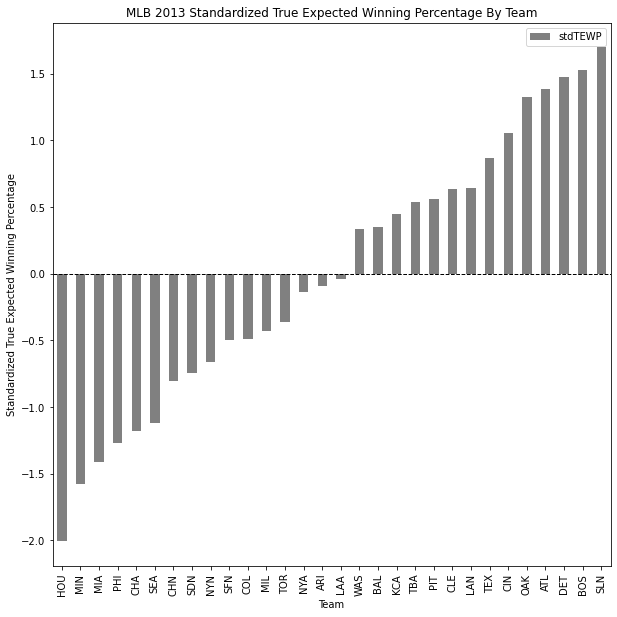

```python
#sort the data by the new stdTEWP this time
newData.sort_values('stdTEWP', inplace=True)
#plot the standardized TEWP
ax = newData.plot.bar(x='TEAM', y='stdTEWP', color = "grey", figsize=(10,10))
#title the plot
ax.title.set_text('MLB 2013 Standardized True Expected Winning Percentage By Team')
#labeling for x and y axis
ax.set_xlabel('Team')
ax.set_ylabel('Standardized True Expected Winning Percentage')
#show the mean (0)
plt.axhline(y=newData['stdTEWP'].mean(), color='k', linestyle='--', linewidth=1)
#show the plot
plt.show()
```

To no surprise, using the standardized TEWP, we can see that the Astros are a staggering -2 on the stdTEWP scale, making them by far the worst team in the league using this classification. Considering this classification is used by not only adjusting for ball parks and using that adjusted runs allowed/scored, but also standardizing to the league to determine just how close or far the Astros were to average, we can see that they are definitively the worst team in the league.

## Conclusion

So were the 2013 Astros the worst team in the league?

During our investigation, we investigated the Houston Astros' performance in the 2013 season using a number of metrics. The first analysis we did was comparing their ERA and BA to the rest of the league. In addition we used BPF and PPF to adjust their runs allowed and scored to calculate their true expected winning percentage of the season. Using all this analysis, I have come to the conclusion that yes, the Houston Astros were the worst team in baseball in 2013, and it wasn't really close.

Judging off their standardized true expected winning percentage of -2, a fairly unbias datapoint given the adjustments made to runs scored/allowed using the PPF and BPF, as well as the fact that it is a standardized statistic, we can decisively conclude that the Houston Astros were the worst team in baseball in the MLB 2013 season. Not only did they have the worst record, worst run differential, worst team ERA and below average team BA, they also had the worst standardized true expected winning percentage cementing them as the worst team in the league by a fairly large margain.

In the bleacherreport's awards for the MLB 2013 season, surprise surprise, the Astros won the worst team award. Link: https://bleacherreport.com/articles/1786050-mlbs-worst-of-award-winners-for-the-2013-season

What a time it was to be an Astros fan.

Thank you for you time in reading the investigation of the 2013 Houston Astros, and I hope I painted a clearer picture on just how bad they were in the 2013 season, and hopefully you got a kick out of how bad they really were.